# SAT_Practice_0317

Question ID: 04_435

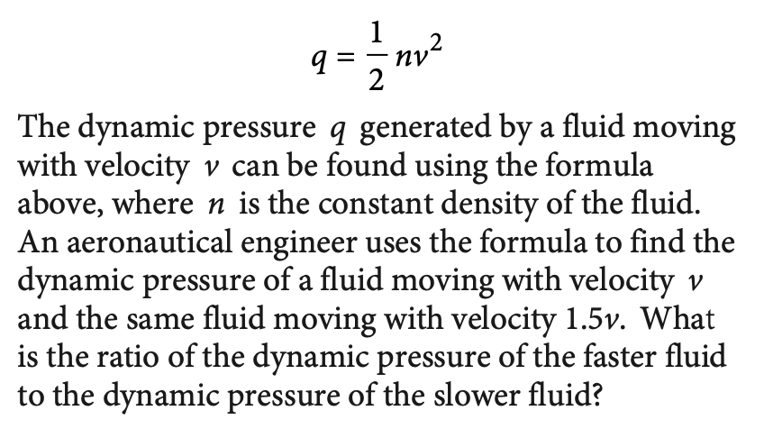

The correct answer is 2.25.

Question ID: 01_418

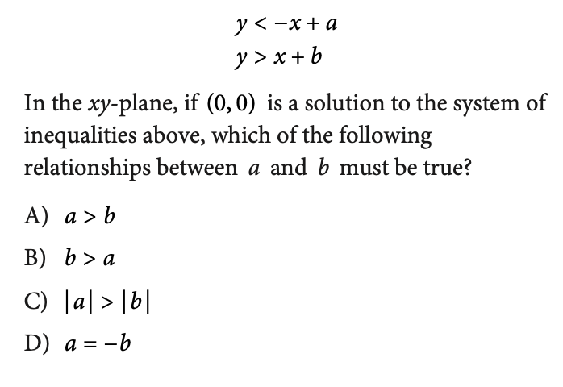

ABCD

The correct answer is A

Question ID: 05_418

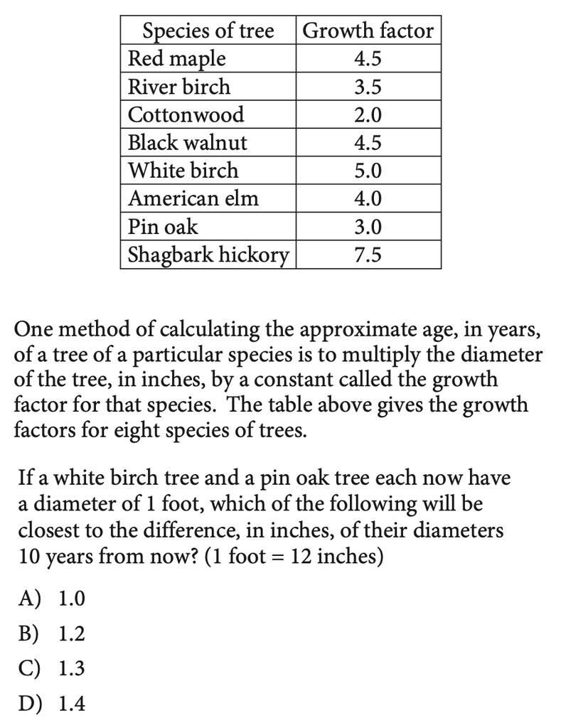

ABCD

The correct answer is C

Question ID: 14_219

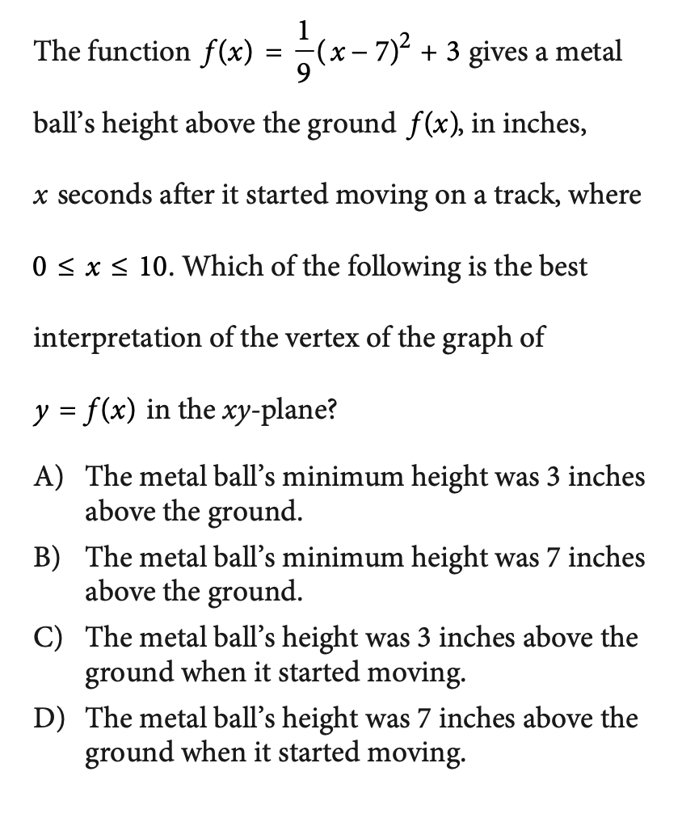

ABCD

The correct answer is A

Question ID: 01_435

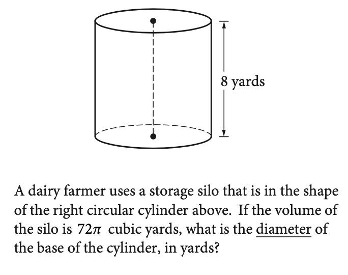

The correct answer is 6.

Question ID: 08_419

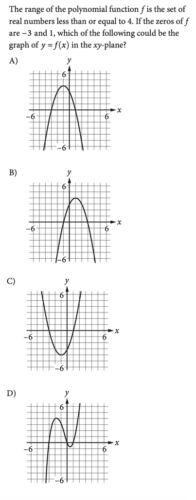

ABCD

The correct answer is A

Question ID: 07_431

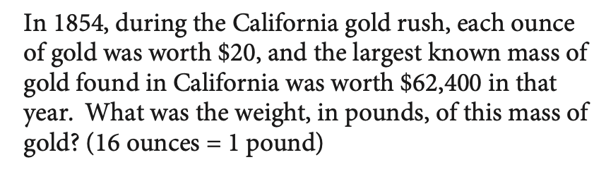

The correct answer is 195.

Question ID: 09_430

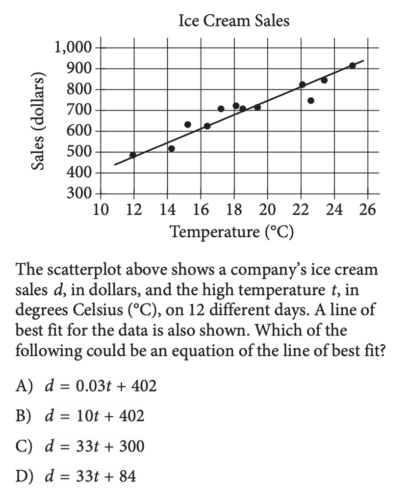

ABCD

The correct answer is D

Question ID: 11_113

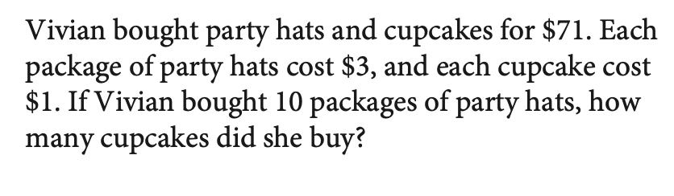

The correct answer is 41.

Question ID: 08_415

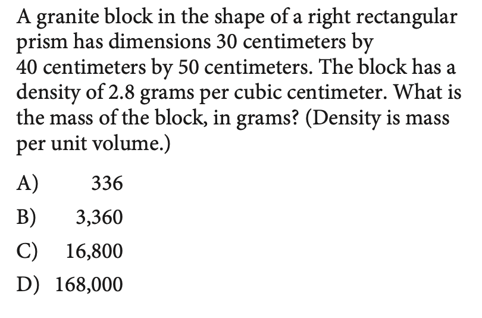

ABCD

The correct answer is D

Question ID: 02_403

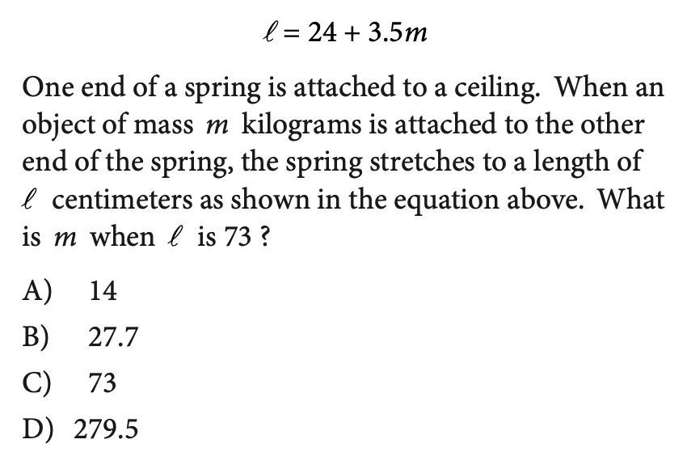

ABCD

The correct answer is A

Question ID: 03_408

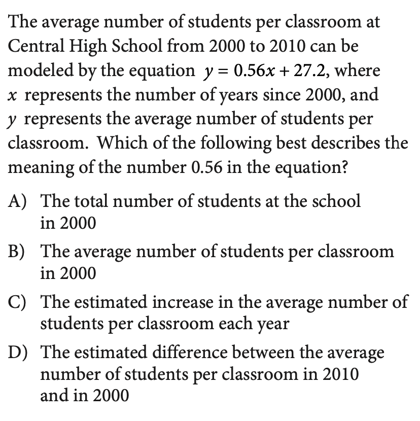

ABCD

The correct answer is C

Question ID: 01_410

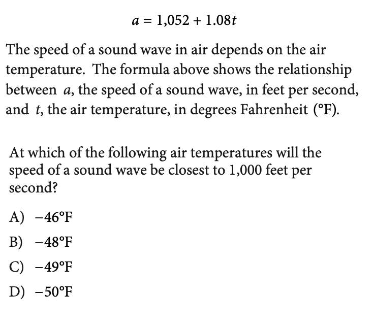

ABCD

The correct answer is B

Question ID: 12_121

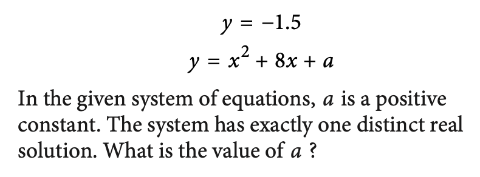

The correct answer is 14.5.

Question ID: 03_304

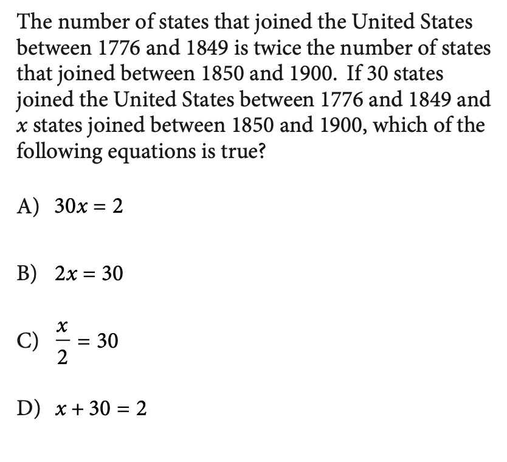

ABCD

The correct answer is B

Question ID: 02_430

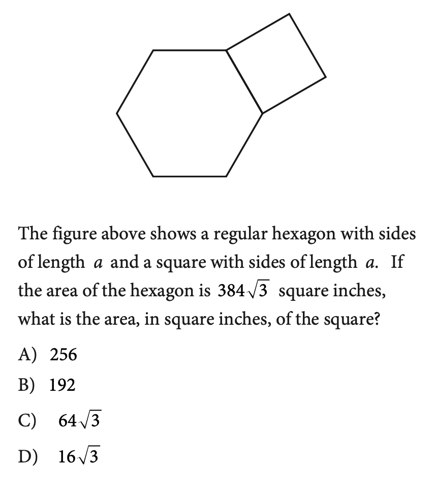

ABCD

The correct answer is A

Question ID: 02_421

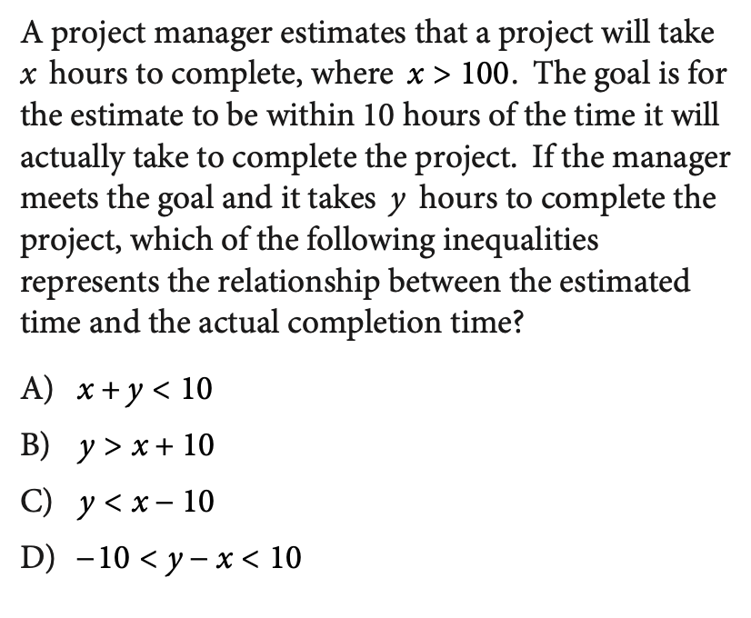

ABCD

The correct answer is D

Question ID: 04_312

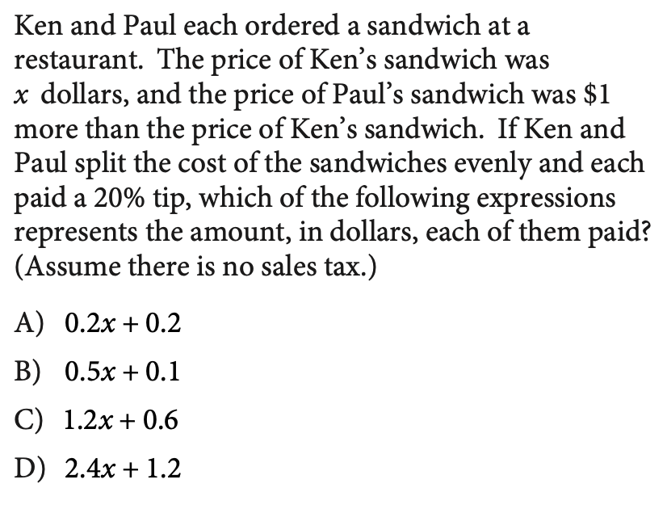

ABCD

The correct answer is C

Question ID: 01_436

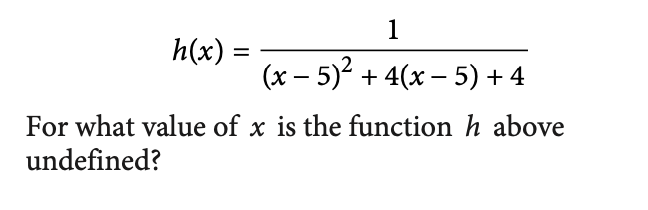

The correct answer is 3.

Question ID: 13_120

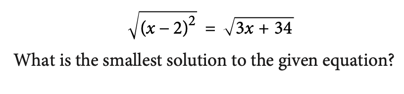

The correct answer is -3.

Question ID: 02_311

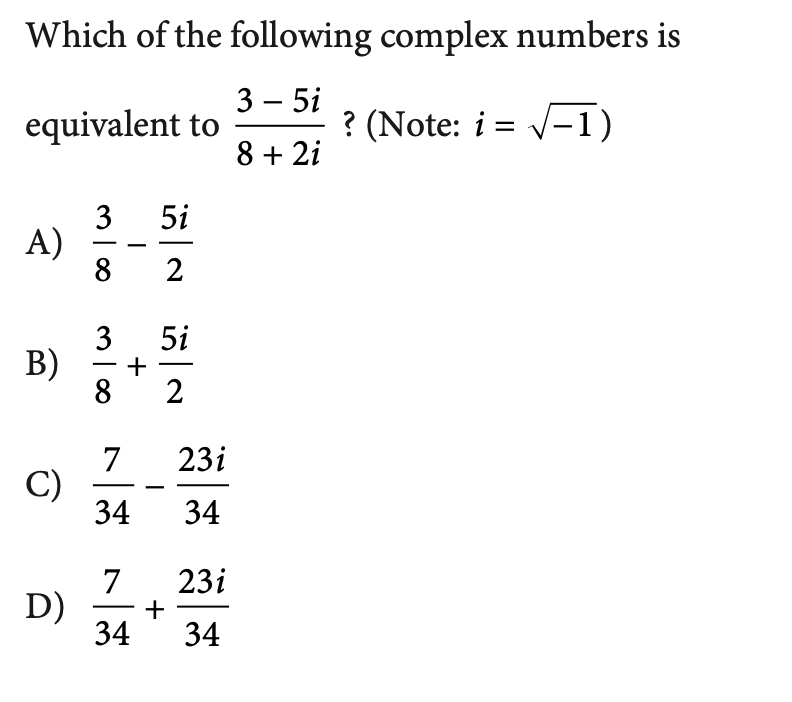

ABCD

The correct answer is C

Question ID: 01_319

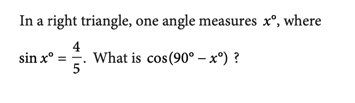

The correct answer is 0.8.

Question ID: 14_218

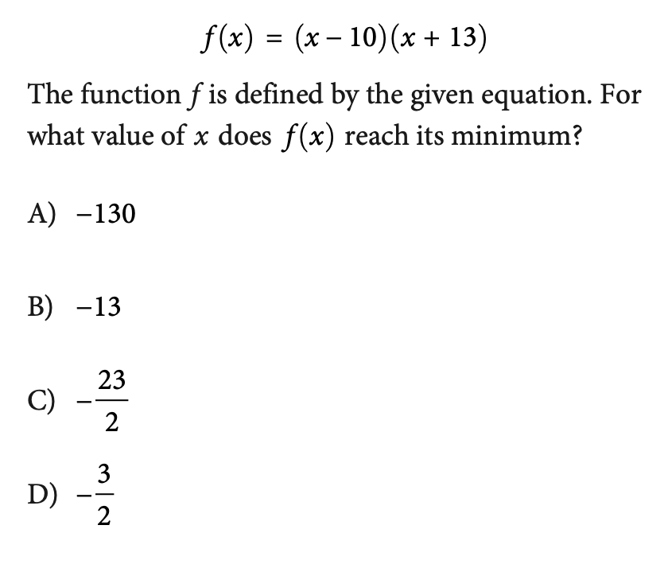

ABCD

The correct answer is D

Question ID: 01_432

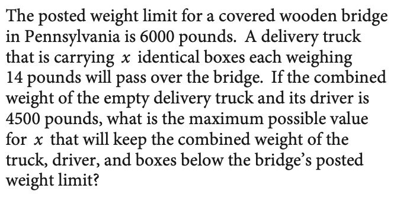

The correct answer is 107.

Question ID: 04_417

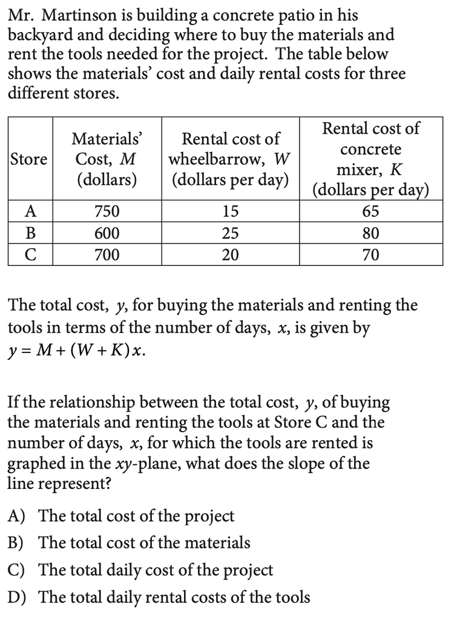

ABCD

The correct answer is D

Question ID: 02_313

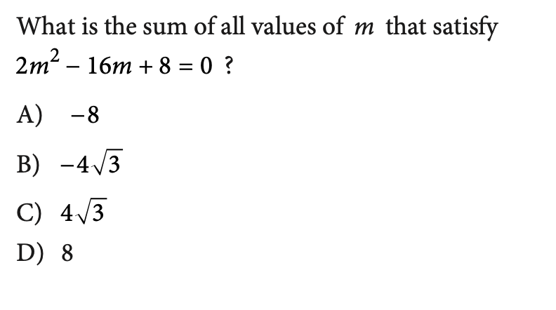

ABCD

The correct answer is D

Question ID: 07_305

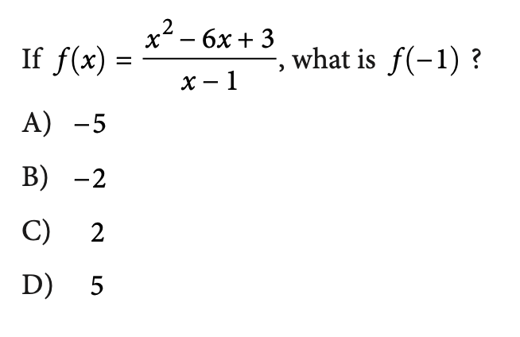

ABCD

The correct answer is A

Question ID: 07_409

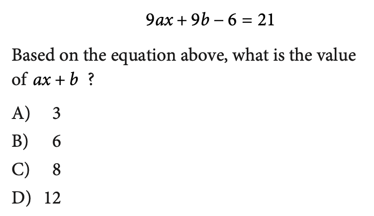

ABCD

The correct answer is A

Question ID: 12_117

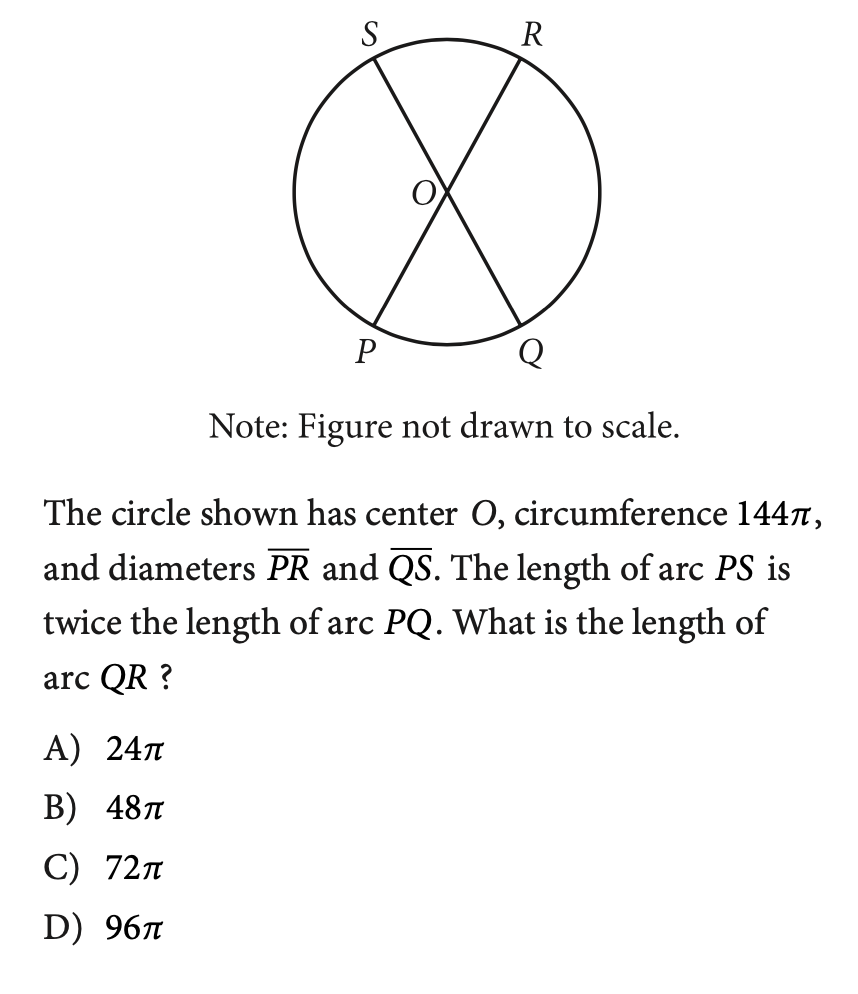

ABCD

The correct answer is B

Question ID: 03_433

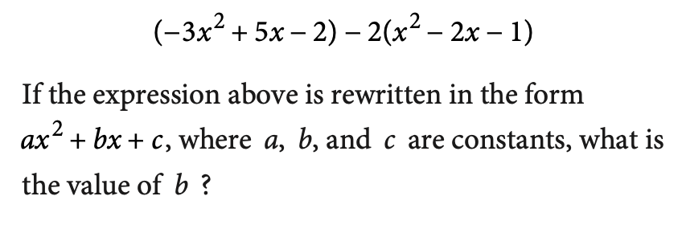

The correct answer is 9.

Question ID: 09_405

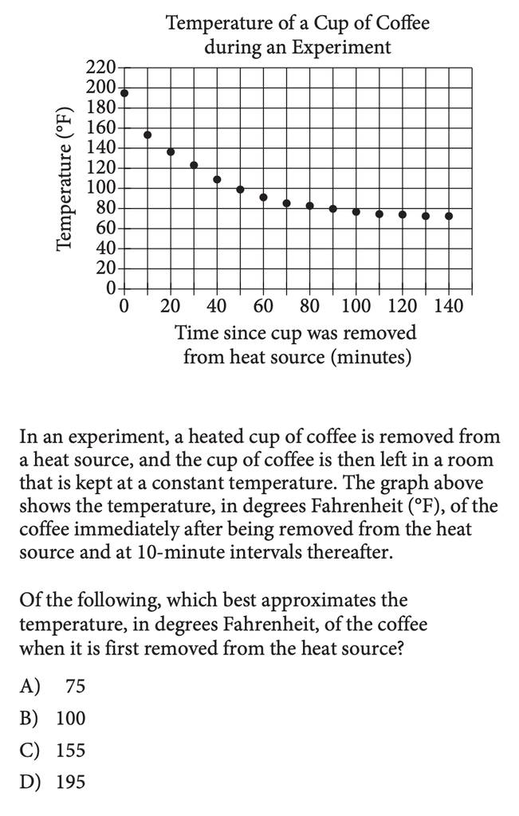

ABCD

The correct answer is D

Question ID: 13_213

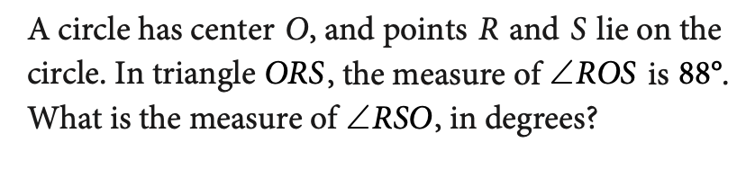

The correct answer is 46.

Question ID: 01_411

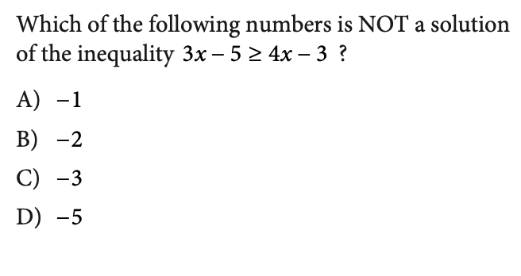

ABCD

The correct answer is A

Question ID: 03_305

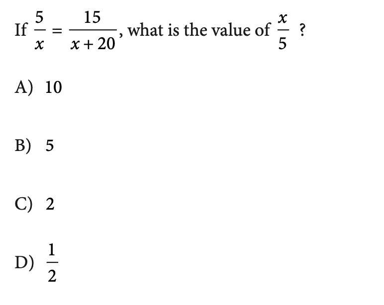

ABCD

The correct answer is C

Question ID: 07_427

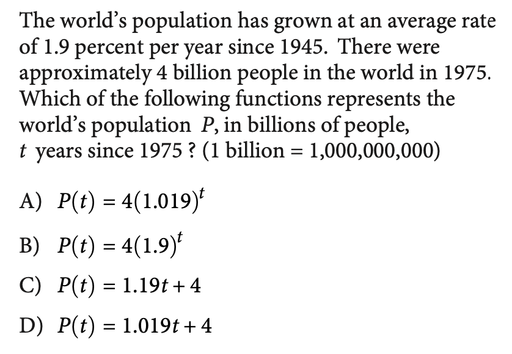

ABCD

The correct answer is A

Question ID: 14_124

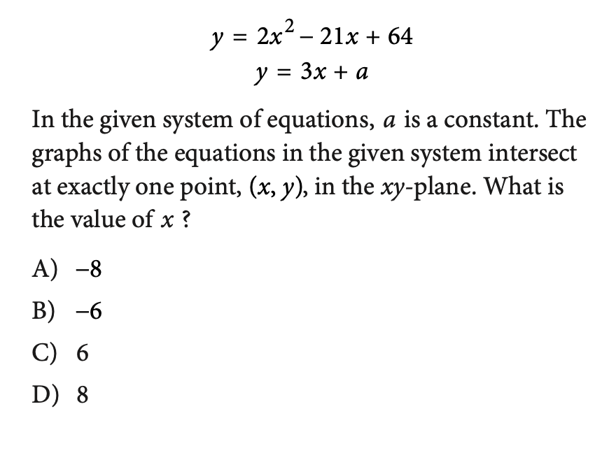

ABCD

The correct answer is C

Question ID: 10_305

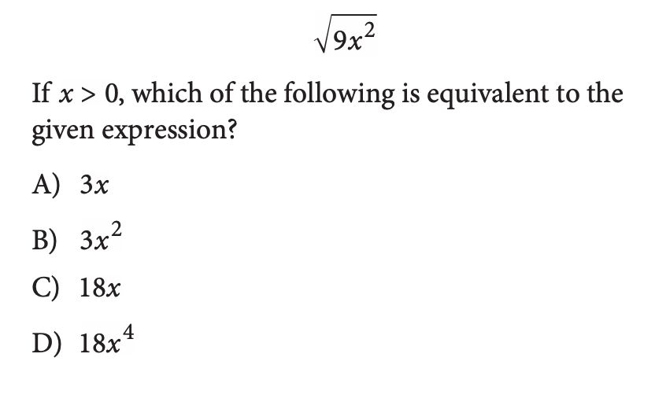

ABCD

The correct answer is A

Question ID: 10_418

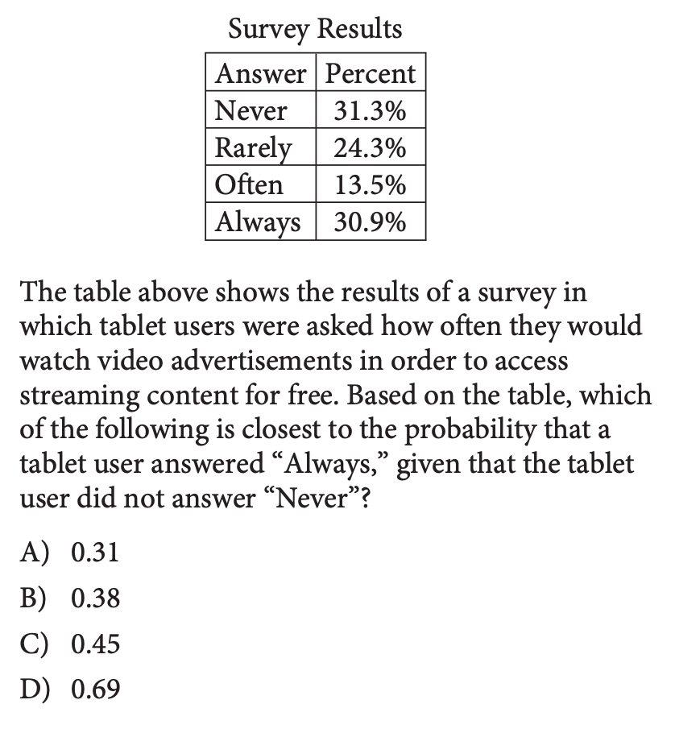

ABCD

The correct answer is C

Question ID: 12_225

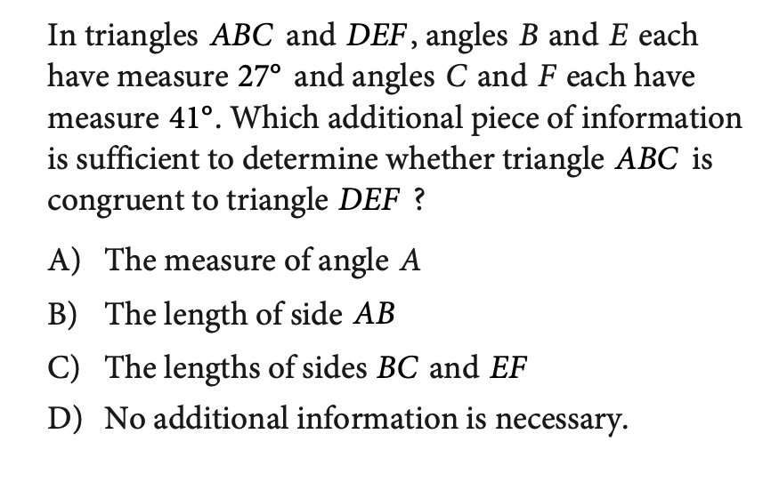

ABCD

The correct answer is C

Question ID: 10_418

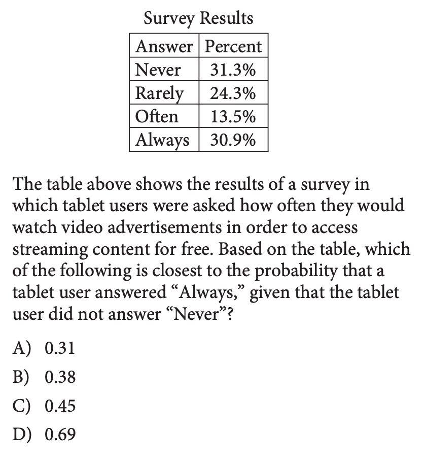

ABCD

The correct answer is C

Question ID: 10_434

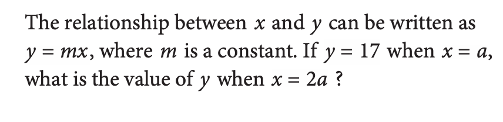

The correct answer is 34.

Question ID: 06_308

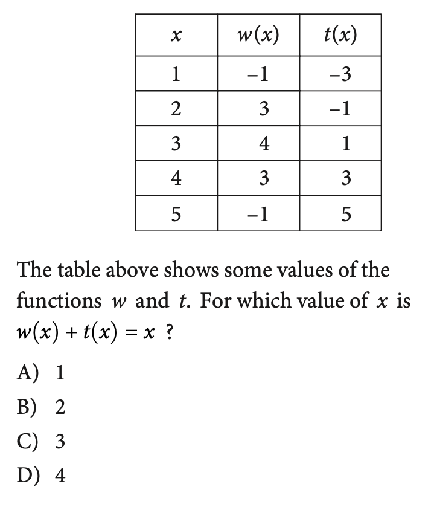

ABCD

The correct answer is B

Question ID: 14_106

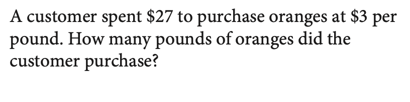

The correct answer is 9.

Question ID: 06_420

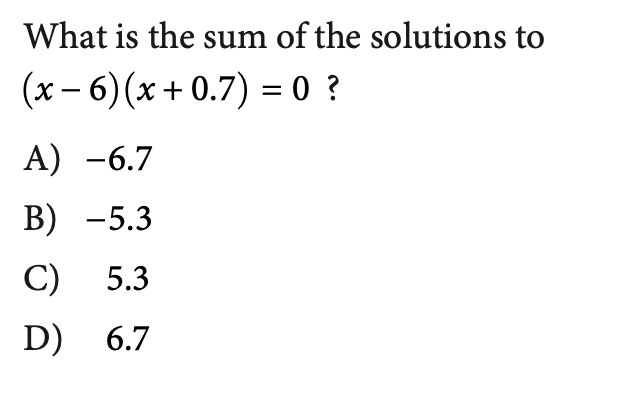

ABCD

The correct answer is C

Question ID: 11_104

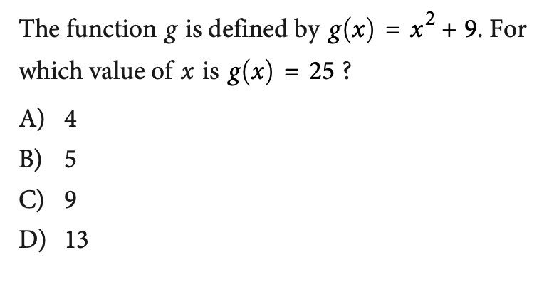

ABCD

The correct answer is A

Question ID: 05_435

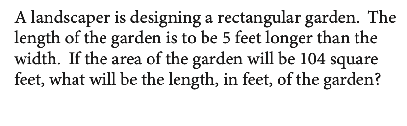

The correct answer is 13.

Question ID: 09_409

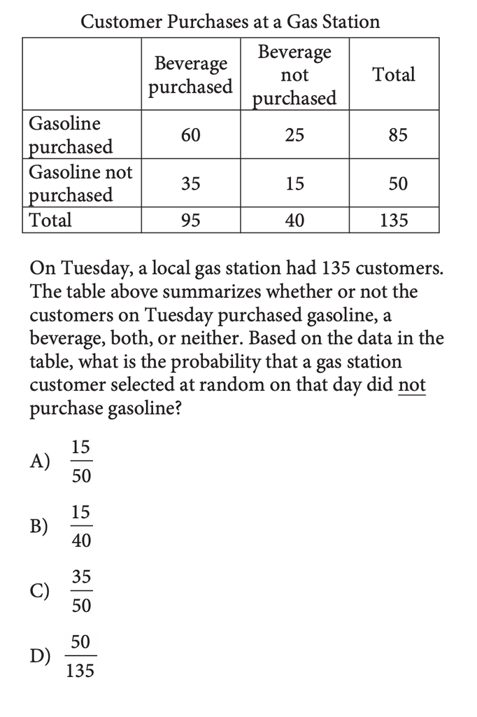

ABCD

The correct answer is D

Question ID: 01_414

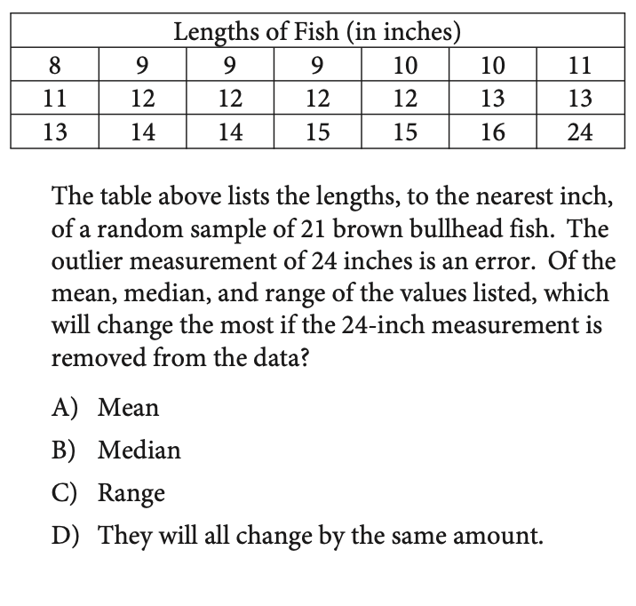

ABCD

The correct answer is C

Question ID: 11_208

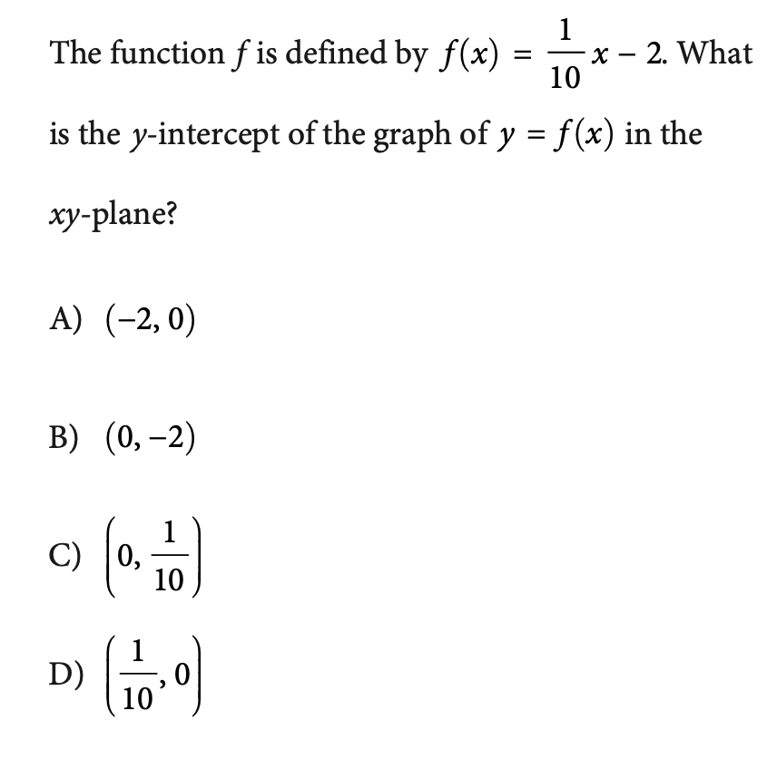

ABCD

The correct answer is B

Question ID: 07_430

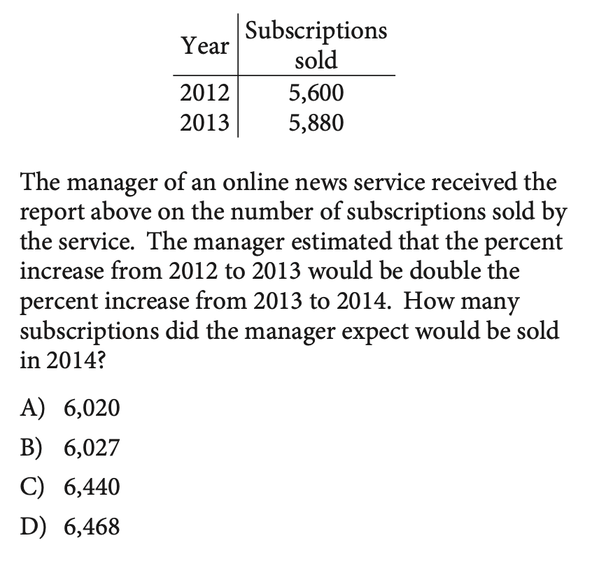

ABCD

The correct answer is B